# Bevan Joubert

## Step 1

```python
# Import all neccessary packages.
import numpy as np
import pandas as pd
import matplotlib.pyplot as plt
import seaborn as sns

from sklearn.model_selection import train_test_split
from sklearn.linear_model import LogisticRegression
from sklearn.metrics import confusion_matrix, recall_score, precision_score, f1_score, roc_auc_score,accuracy_score

from IPython.core.interactiveshell import InteractiveShell
```

```python
# Import the dataset.
bankData = pd.read_csv("Bank_Personal_Loan_Modelling.csv")
```

```python
# Get a brief overview of the data.
bankData.head()
```

|  | ID | Age | Experience | Income | ZIP Code | Family | CCAvg | Education | Mortgage | Personal Loan | Securities Account | CD Account | Online | CreditCard |
| --- | --- | --- | --- | --- | --- | --- | --- | --- | --- | --- | --- | --- | --- | --- |
| 0 | 1 | 25 | 1 | 49 | 91107 | 4 | 1.6 | 1 | 0 | 0 | 1 | 0 | 0 | 0 |
| 1 | 2 | 45 | 19 | 34 | 90089 | 3 | 1.5 | 1 | 0 | 0 | 1 | 0 | 0 | 0 |
| 2 | 3 | 39 | 15 | 11 | 94720 | 1 | 1.0 | 1 | 0 | 0 | 0 | 0 | 0 | 0 |
| 3 | 4 | 35 | 9 | 100 | 94112 | 1 | 2.7 | 2 | 0 | 0 | 0 | 0 | 0 | 0 |
| 4 | 5 | 35 | 8 | 45 | 91330 | 4 | 1.0 | 2 | 0 | 0 | 0 | 0 | 0 | 1 |

```python
# See the shape of the dataset.
bankData.shape
```

```
(5000, 14)
```

```python
# Check for null values.
bankData.isnull().any()
```

```
ID                    False
Age                   False
Experience            False
Income                False
ZIP Code              False
Family                False
CCAvg                 False
Education             False
Mortgage              False
Personal Loan         False
Securities Account    False
CD Account            False
Online                False
CreditCard            False
dtype: bool
```

```python
# Check all the datatypes, can also be use to check for null values.
bankData.info()
```

```
<class 'pandas.core.frame.DataFrame'>
RangeIndex: 5000 entries, 0 to 4999
Data columns (total 14 columns):
 #   Column              Non-Null Count  Dtype
---  ------              --------------  -----
 0   ID                  5000 non-null   int64
 1   Age                 5000 non-null   int64
 2   Experience          5000 non-null   int64
 3   Income              5000 non-null   int64
 4   ZIP Code            5000 non-null   int64
 5   Family              5000 non-null   int64
 6   CCAvg               5000 non-null   float64
 7   Education           5000 non-null   int64
 8   Mortgage            5000 non-null   int64
 9   Personal Loan       5000 non-null   int64
 10  Securities Account  5000 non-null   int64
 11  CD Account          5000 non-null   int64
 12  Online              5000 non-null   int64
 13  CreditCard          5000 non-null   int64
dtypes: float64(1), int64(13)
memory usage: 547.0 KB
```

```python
# All datatypes are numerical, which means that there are no string values.
# 'ZIP Code' should be changed to a category type later.
# 'Personal Loan', 'Securities Account', 'CD Account', 'Online', 'Credit Card' are also categorical,
# but they can be seen as already being one-hot encoded.
# Although there are no null values, 'Age' and 'ZIP' should not have values which equal zero, check for these.
print("Entries where 'Age' is '0':\t\t{}".format(bankData[bankData['Age']==0].count()[0]))
print("Entries where 'ZIP code' is '0':\t{}".format(bankData[bankData['ZIP Code']==0].count()[0]))
```

```
Entries where 'Age' is '0':		0
Entries where 'ZIP code' is '0':	0
```

```python
# It seems that the data has been well collected and that there are no missing values and only one incorrect zip code.
# Get the statistical infromation of the dataset.
bankData.describe().transpose()
```

|  | count | mean | std | min | 25% | 50% | 75% | max |
| --- | --- | --- | --- | --- | --- | --- | --- | --- |
| ID | 5000.0 | 2500.500000 | 1443.520003 | 1.0 | 1250.75 | 2500.5 | 3750.25 | 5000.0 |
| Age | 5000.0 | 45.338400 | 11.463166 | 23.0 | 35.00 | 45.0 | 55.00 | 67.0 |
| Experience | 5000.0 | 20.104600 | 11.467954 | -3.0 | 10.00 | 20.0 | 30.00 | 43.0 |
| Income | 5000.0 | 73.774200 | 46.033729 | 8.0 | 39.00 | 64.0 | 98.00 | 224.0 |
| ZIP Code | 5000.0 | 93152.503000 | 2121.852197 | 9307.0 | 91911.00 | 93437.0 | 94608.00 | 96651.0 |
| Family | 5000.0 | 2.396400 | 1.147663 | 1.0 | 1.00 | 2.0 | 3.00 | 4.0 |
| CCAvg | 5000.0 | 1.937938 | 1.747659 | 0.0 | 0.70 | 1.5 | 2.50 | 10.0 |
| Education | 5000.0 | 1.881000 | 0.839869 | 1.0 | 1.00 | 2.0 | 3.00 | 3.0 |
| Mortgage | 5000.0 | 56.498800 | 101.713802 | 0.0 | 0.00 | 0.0 | 101.00 | 635.0 |
| Personal Loan | 5000.0 | 0.096000 | 0.294621 | 0.0 | 0.00 | 0.0 | 0.00 | 1.0 |
| Securities Account | 5000.0 | 0.104400 | 0.305809 | 0.0 | 0.00 | 0.0 | 0.00 | 1.0 |
| CD Account | 5000.0 | 0.060400 | 0.238250 | 0.0 | 0.00 | 0.0 | 0.00 | 1.0 |
| Online | 5000.0 | 0.596800 | 0.490589 | 0.0 | 0.00 | 1.0 | 1.00 | 1.0 |
| CreditCard | 5000.0 | 0.294000 | 0.455637 | 0.0 | 0.00 | 0.0 | 1.00 | 1.0 |

```python
# The minimum "ZIP Code" seems to be quite far away from the other zip code values.
# Most zip codes have the format 9xxxx. Check to see how many are smaller than 90000.
print("Entries where 'ZIP code' is <90000:\t{}".format(bankData[bankData['ZIP Code']<90000].count()[0]))
bankData[bankData['ZIP Code']<90000]
```

```
Entries where 'ZIP code' is <90000:	1
```

|  | ID | Age | Experience | Income | ZIP Code | Family | CCAvg | Education | Mortgage | Personal Loan | Securities Account | CD Account | Online | CreditCard |
| --- | --- | --- | --- | --- | --- | --- | --- | --- | --- | --- | --- | --- | --- | --- |
| 384 | 385 | 51 | 25 | 21 | 9307 | 4 | 0.6 | 3 | 0 | 0 | 0 | 0 | 1 | 1 |

```python
# It is safe to assume that if this is the only zip code out of 5000 which is not in the same format, then it is wrong.
# Assume a typing error and just add an extra 0 at the end.
```

### Repair the Data

```python
# First create a dataset where all the data will be fixed.
bankData_f = bankData.copy() # _f suffix for fixed.
# Drop the ID column as this is unique for each entry and provides no information.
bankData_f.drop(columns=['ID'], inplace=True)
# Move the 'Personal Loan' column to the end of the dataframe, it is more intuitive to have the outcome at the end.
bankData_f.drop(columns=['Personal Loan'], inplace = True)
bankData_f['Personal Loan'] = bankData['Personal Loan']
# Fix the errenious ZIP Code.
zipCol = bankData_f.index[bankData_f['ZIP Code']<90000][0]
bankData_f.at[zipCol, 'ZIP Code'] *= 10
bankData_f[bankData_f['ZIP Code']==93070]['ZIP Code'].count()
```

```
1
```

```python
# There is only one value with the new 'ZIP Code', so the number of unique ZIP codes stays the same.
```

```python
# The minimum Experience is also supicious, since it is not possible to have les than 0 years of experience.
# Check to see how many 'Experience' values are negative.
print("Entries where 'Experience' is <0:\t{}".format(bankData_f[bankData_f['Experience']<0].count()[0]))
bankData_f[bankData_f['Experience']<0].head(10)
```

```
Entries where 'Experience' is <0:	52
```

|  | Age | Experience | Income | ZIP Code | Family | CCAvg | Education | Mortgage | Securities Account | CD Account | Online | CreditCard | Personal Loan |
| --- | --- | --- | --- | --- | --- | --- | --- | --- | --- | --- | --- | --- | --- |
| 89 | 25 | -1 | 113 | 94303 | 4 | 2.30 | 3 | 0 | 0 | 0 | 0 | 1 | 0 |
| 226 | 24 | -1 | 39 | 94085 | 2 | 1.70 | 2 | 0 | 0 | 0 | 0 | 0 | 0 |
| 315 | 24 | -2 | 51 | 90630 | 3 | 0.30 | 3 | 0 | 0 | 0 | 1 | 0 | 0 |
| 451 | 28 | -2 | 48 | 94132 | 2 | 1.75 | 3 | 89 | 0 | 0 | 1 | 0 | 0 |
| 524 | 24 | -1 | 75 | 93014 | 4 | 0.20 | 1 | 0 | 0 | 0 | 1 | 0 | 0 |
| 536 | 25 | -1 | 43 | 92173 | 3 | 2.40 | 2 | 176 | 0 | 0 | 1 | 0 | 0 |
| 540 | 25 | -1 | 109 | 94010 | 4 | 2.30 | 3 | 314 | 0 | 0 | 1 | 0 | 0 |
| 576 | 25 | -1 | 48 | 92870 | 3 | 0.30 | 3 | 0 | 0 | 0 | 0 | 1 | 0 |
| 583 | 24 | -1 | 38 | 95045 | 2 | 1.70 | 2 | 0 | 0 | 0 | 1 | 0 | 0 |
| 597 | 24 | -2 | 125 | 92835 | 2 | 7.20 | 1 | 0 | 1 | 0 | 0 | 1 | 0 |

```python
# All these customers are in their 20s, maybe the negative number indicates that they are still studying.
# However, there are 'Education' levels of 1, 2 and 3 here, clients with level 3 education are unlikely to still be students.
# Furthermore, some of the users already have income and mortgage, so it is unlikely that all of them are still students.
# A negative value could be some form of a penalty based on some factor.
# Since the dataset briefing makes no mention of negative years of experience, I will assume that these entries are errenious.
# Three ways to deal with this:
# 1. Make all negative values 0.
# 2. Invert the sign of all negative values, this makes more sense since these users all have non-zero incomes which
#    implies that their experience is not 0 and therefore only the '-' character was input incorrectly.
# 3. Give each a new Experience value base on their income and education level. This will require analysing and categorising
#    the other entries first and I think would be beyond the scope of this project.
# Method 1 and 2 would be very similar since all the negative values are between 0 and -3, which is quite close to 0.
# Use method 2 since method 3 would be a small project of its own.
```

```python
for i in bankData_f.index[bankData_f['Experience']<0]:
    bankData_f.at[i, 'Experience'] *= -1
```

```python
# Check if the alteration was successful.
bankData_f[bankData['Experience']<0].head(10)
```

|  | Age | Experience | Income | ZIP Code | Family | CCAvg | Education | Mortgage | Securities Account | CD Account | Online | CreditCard | Personal Loan |
| --- | --- | --- | --- | --- | --- | --- | --- | --- | --- | --- | --- | --- | --- |
| 89 | 25 | 1 | 113 | 94303 | 4 | 2.30 | 3 | 0 | 0 | 0 | 0 | 1 | 0 |
| 226 | 24 | 1 | 39 | 94085 | 2 | 1.70 | 2 | 0 | 0 | 0 | 0 | 0 | 0 |
| 315 | 24 | 2 | 51 | 90630 | 3 | 0.30 | 3 | 0 | 0 | 0 | 1 | 0 | 0 |
| 451 | 28 | 2 | 48 | 94132 | 2 | 1.75 | 3 | 89 | 0 | 0 | 1 | 0 | 0 |
| 524 | 24 | 1 | 75 | 93014 | 4 | 0.20 | 1 | 0 | 0 | 0 | 1 | 0 | 0 |
| 536 | 25 | 1 | 43 | 92173 | 3 | 2.40 | 2 | 176 | 0 | 0 | 1 | 0 | 0 |
| 540 | 25 | 1 | 109 | 94010 | 4 | 2.30 | 3 | 314 | 0 | 0 | 1 | 0 | 0 |
| 576 | 25 | 1 | 48 | 92870 | 3 | 0.30 | 3 | 0 | 0 | 0 | 0 | 1 | 0 |
| 583 | 24 | 1 | 38 | 95045 | 2 | 1.70 | 2 | 0 | 0 | 0 | 1 | 0 | 0 |
| 597 | 24 | 2 | 125 | 92835 | 2 | 7.20 | 1 | 0 | 1 | 0 | 0 | 1 | 0 |

```python
# Expereince values fixed successfully.
# Now change all the categorical columns to categorical datatypes.
bankData_f['ZIP Code'] = bankData_f['ZIP Code'].astype('category')
bankData_f['Education'] = bankData_f['Education'].astype('category')
bankData_f['Personal Loan'] = bankData_f['Personal Loan'].astype('category')
bankData_f['Securities Account'] = bankData_f['Securities Account'].astype('category')
bankData_f['CD Account'] = bankData_f['CD Account'].astype('category')
bankData_f['Online'] = bankData_f['Online'].astype('category')
bankData_f['CreditCard'] = bankData_f['CreditCard'].astype('category')
```

```python
# Describe the fixed dataset.
bankData_f.describe().transpose()
```

|  | count | mean | std | min | 25% | 50% | 75% | max |
| --- | --- | --- | --- | --- | --- | --- | --- | --- |
| Age | 5000.0 | 45.338400 | 11.463166 | 23.0 | 35.0 | 45.0 | 55.0 | 67.0 |
| Experience | 5000.0 | 20.134600 | 11.415189 | 0.0 | 10.0 | 20.0 | 30.0 | 43.0 |
| Income | 5000.0 | 73.774200 | 46.033729 | 8.0 | 39.0 | 64.0 | 98.0 | 224.0 |
| Family | 5000.0 | 2.396400 | 1.147663 | 1.0 | 1.0 | 2.0 | 3.0 | 4.0 |
| CCAvg | 5000.0 | 1.937938 | 1.747659 | 0.0 | 0.7 | 1.5 | 2.5 | 10.0 |
| Mortgage | 5000.0 | 56.498800 | 101.713802 | 0.0 | 0.0 | 0.0 | 101.0 | 635.0 |

```python
# No data seems out of the ordinary, although the 'Mortgage' value is very biased towards 0 which shows that not many people
# have mortgages.
```

## Step 2

```python
# Find the number of unique values for each column.
bankData_f.nunique()
```

```
Age                    45
Experience             44
Income                162
ZIP Code              467
Family                  4
CCAvg                 108
Education               3
Mortgage              347
Securities Account      2
CD Account              2
Online                  2
CreditCard              2
Personal Loan           2
dtype: int64
```

```python
# How many people have zero mortgage?
print("Number of people with zero mortgage: ", bankData_f[bankData_f['Mortgage'] == 0].count()[0])
```

```
Number of people with zero mortgage:  3462
```

```python
# That explains the bias towards 0 of the mortgage column, this is probably a dataset of millenials (just kidding).
```

```python
# How many people have zero credit card expenditure per month?
print("Number of people with zero credit card expenditure on average per month: ",
      bankData_f[bankData_f['CCAvg'] == 0].count()[0])
```

```
Number of people with zero credit card expenditure on average per month:  106
```

```python
# The number of unique values for each column has already been shown.
# Now show how many entries there are for each unique value of the categorical columns.
from pandas.api.types import is_categorical_dtype
for column in bankData_f:
    if(is_categorical_dtype(bankData_f[column])):
        print("Value Counts for: ", column)
        print(bankData_f[column].value_counts().sort_values(ascending=False))
        print()
```

```
Value Counts for:  ZIP Code
94720    169
94305    127
95616    116
90095     71
93106     57
        ...
92694      1
93070      1
96145      1
94087      1
90813      1
Name: ZIP Code, Length: 467, dtype: int64

Value Counts for:  Education
1    2096
3    1501
2    1403
Name: Education, dtype: int64

Value Counts for:  Securities Account
0    4478
1     522
Name: Securities Account, dtype: int64

Value Counts for:  CD Account
0    4698
1     302
Name: CD Account, dtype: int64

Value Counts for:  Online
1    2984
0    2016
Name: Online, dtype: int64

Value Counts for:  CreditCard
0    3530
1    1470
Name: CreditCard, dtype: int64

Value Counts for:  Personal Loan
0    4520
1     480
Name: Personal Loan, dtype: int64
```

### Univariate Analysis

```
array([[<matplotlib.axes._subplots.AxesSubplot object at 0x0000020F0D58CA88>,
      dtype=object)
```

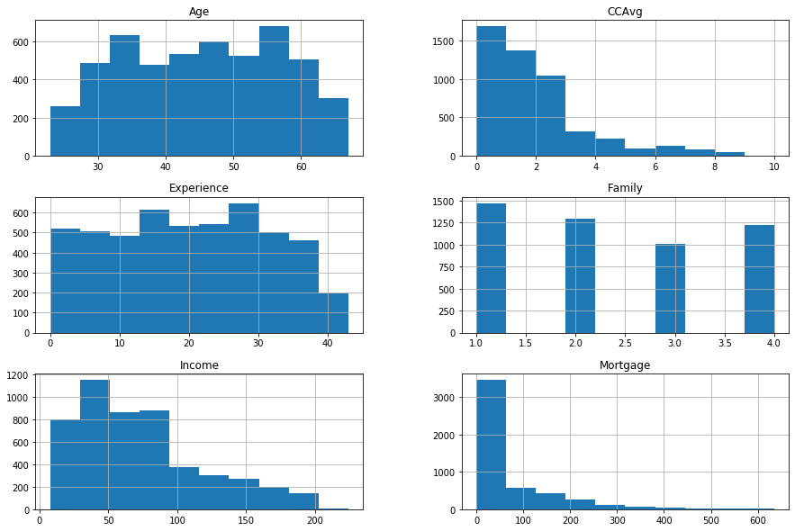

```python
# Plot histograms of all the numerical data.
bankData_f.hist(figsize=(15,10))
```

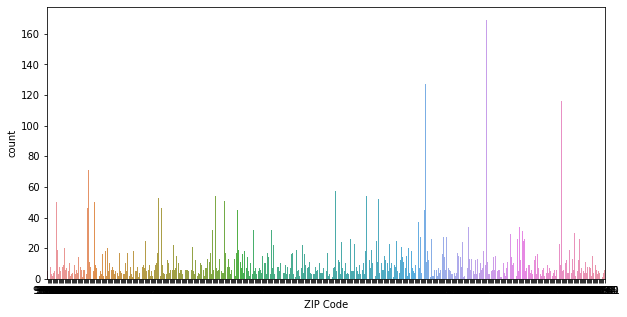

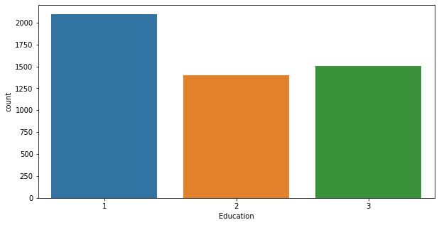

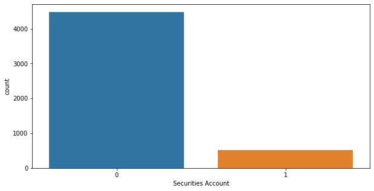

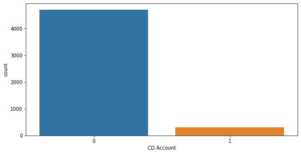

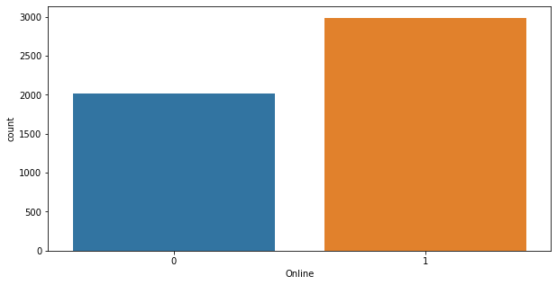

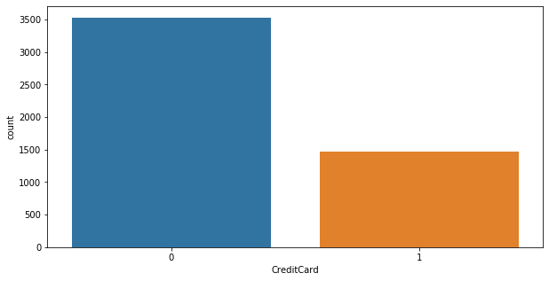

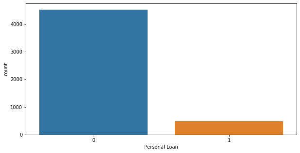

```python
# Countplot of all categorical values.
figCount = 0
for column in bankData_f:
    if(is_categorical_dtype(bankData_f[column])):
        figCount += 1
        plt.figure(figCount, figsize=(10,5))
        sns.countplot(bankData_f[column])
```

### Bivariate Analysis

```python
bankData_f.head()
```

|  | Age | Experience | Income | ZIP Code | Family | CCAvg | Education | Mortgage | Securities Account | CD Account | Online | CreditCard | Personal Loan |
| --- | --- | --- | --- | --- | --- | --- | --- | --- | --- | --- | --- | --- | --- |
| 0 | 25 | 1 | 49 | 91107 | 4 | 1.6 | 1 | 0 | 1 | 0 | 0 | 0 | 0 |
| 1 | 45 | 19 | 34 | 90089 | 3 | 1.5 | 1 | 0 | 1 | 0 | 0 | 0 | 0 |
| 2 | 39 | 15 | 11 | 94720 | 1 | 1.0 | 1 | 0 | 0 | 0 | 0 | 0 | 0 |
| 3 | 35 | 9 | 100 | 94112 | 1 | 2.7 | 2 | 0 | 0 | 0 | 0 | 0 | 0 |
| 4 | 35 | 8 | 45 | 91330 | 4 | 1.0 | 2 | 0 | 0 | 0 | 0 | 1 | 0 |

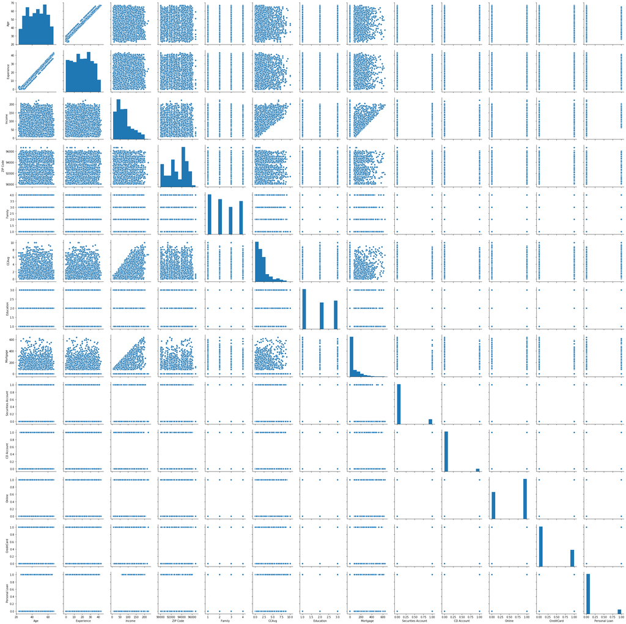

```python
plt.figure(0)
prplt = sns.pairplot(bankData_f)
```

```python
# See if any columns are highly correlated.
bankData_f.corr()
```

|  | Age | Experience | Income | Family | CCAvg | Mortgage |
| --- | --- | --- | --- | --- | --- | --- |
| Age | 1.000000 | 0.993991 | -0.055269 | -0.046418 | -0.052012 | -0.012539 |
| Experience | 0.993991 | 1.000000 | -0.046876 | -0.051851 | -0.049738 | -0.011097 |
| Income | -0.055269 | -0.046876 | 1.000000 | -0.157501 | 0.645984 | 0.206806 |
| Family | -0.046418 | -0.051851 | -0.157501 | 1.000000 | -0.109275 | -0.020445 |
| CCAvg | -0.052012 | -0.049738 | 0.645984 | -0.109275 | 1.000000 | 0.109905 |
| Mortgage | -0.012539 | -0.011097 | 0.206806 | -0.020445 | 0.109905 | 1.000000 |

```python
InteractiveShell.ast_node_interactivity = "all"
```

```python
# Look if there is any relationship between the categorical values and the Loan status.
for i in list(bankData_f.columns[bankData_f.dtypes=='category']):
    temp_df = pd.crosstab(bankData_f[i],bankData_f['Personal Loan']).sort_values(by=1, ascending=False)
    temp_df.columns = temp_df.columns.add_categories('% Success')
    temp_df['% Success'] = (round(temp_df[1].div(temp_df[0].add(temp_df[1]))*100,2))
    temp_df.head(15)
    print()
```

| Personal Loan ZIP Code | 0 | 1 | % Success |
| --- | --- | --- | --- |
| 94720 | 150 | 19 | 11.24 |
| 94305 | 114 | 13 | 10.24 |
| 92093 | 42 | 9 | 17.65 |
| 90095 | 63 | 8 | 11.27 |
| 90089 | 38 | 8 | 17.39 |
| 94304 | 37 | 8 | 17.78 |
| 92182 | 25 | 7 | 21.88 |
| 95616 | 110 | 6 | 5.17 |
| 94022 | 19 | 6 | 24.00 |
| 95051 | 28 | 6 | 17.65 |
| 91380 | 17 | 5 | 22.73 |
| 90245 | 45 | 5 | 10.00 |
| 94928 | 10 | 5 | 33.33 |
| 92037 | 49 | 5 | 9.26 |
| 95054 | 26 | 5 | 16.13 |

| Personal Loan Education | 0 | 1 | % Success |
| --- | --- | --- | --- |
| 3 | 1296 | 205 | 13.66 |
| 2 | 1221 | 182 | 12.97 |
| 1 | 2003 | 93 | 4.44 |

| Personal Loan Securities Account | 0 | 1 | % Success |
| --- | --- | --- | --- |
| 0 | 4058 | 420 | 9.38 |
| 1 | 462 | 60 | 11.49 |

| Personal Loan CD Account | 0 | 1 | % Success |
| --- | --- | --- | --- |
| 0 | 4358 | 340 | 7.24 |
| 1 | 162 | 140 | 46.36 |

| Personal Loan Online | 0 | 1 | % Success |
| --- | --- | --- | --- |
| 1 | 2693 | 291 | 9.75 |
| 0 | 1827 | 189 | 9.38 |

| Personal Loan CreditCard | 0 | 1 | % Success |
| --- | --- | --- | --- |
| 0 | 3193 | 337 | 9.55 |
| 1 | 1327 | 143 | 9.73 |

| Personal Loan | 0 | 1 | % Success |
| --- | --- | --- | --- |
| 1 | 0 | 480 | 100.0 |
| 0 | 4520 | 0 | 0.0 |

```python
InteractiveShell.ast_node_interactivity = "last_expr"
```

### Crosstab Observations

- The largest amount of people from one area that took loans is 19, by looking at the value counts, this is also the area with the most bank customers. Precentage the relation to are seems quite random.
- The Advanced/Professional education group took the most personal loans percentage wise.
- People who make use of basic banking services such as online banking and a credit card are just as likely to take the loan as people who do not use these services.
- People who make use of advanced banking services such as Securities and CD Accounts are more likely to take the personal loan.

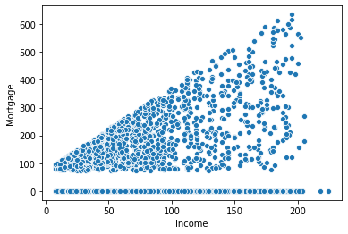

```python
# Let's check the mortgage vs income.
sns.scatterplot(x='Income', y='Mortgage', data=bankData_f)
```

```python
print("Percentage of dataset entries who have mrotgage: {:.2f}%".format((bankData_f[bankData_f['Mortgage'] != 0].count()[0])/bankData.shape[0]*100))
```

```
Percentage of dataset entries who have mrotgage: 30.76%
```

```python
print("The ratio of the total mortgage vs total yearly income of the dataset is: {:.2f}".format(bankData_f['Mortgage'].sum()/bankData_f['Income'].sum()))
print("This is quite low since a person's mortgage is normally multiples of their yearly income.")
```

```
The ratio of the total mortgage vs total yearly income of the dataset is: 0.77
This is quite low since a person's mortgage is normally multiples of their yearly income.
```

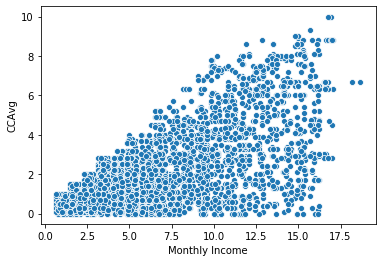

```python
# Let's check the monthly credit expenditure vs monthly income.
creditVsIncome = pd.DataFrame({"Monthly Income" : bankData_f['Income']/12, 'CCAvg' : bankData_f['CCAvg']})
sns.scatterplot(x='Monthly Income', y='CCAvg', data=creditVsIncome)
```

```python
print("Percentage of dataset entries whp have credit card expenditure is: {:.2f}%".format((bankData_f[bankData_f['CCAvg'] != 0].count()[0])/bankData.shape[0]*100))
print()
print("The average ratio of credit card expenditure vs monthly income of the dataset is: {:.3f}".format(creditVsIncome['CCAvg'].div(creditVsIncome['Monthly Income'], axis='index').mean()))
print()
print("The ratio of total credit card expenditure vs total monthly income of the dataset is: {:.3f}".format(creditVsIncome['CCAvg'].sum()/creditVsIncome['Monthly Income'].sum()))
print()
print("The data briefing does not make it clear wether this is credit or just payments made via credit card,\nbut it can be seen that people make use of their credit cards.")
```

```
Percentage of dataset entries whp have credit card expenditure is: 97.88%

The average ratio of credit card expenditure vs monthly income of the dataset is: 0.333

The ratio of total credit card expenditure vs total monthly income of the dataset is: 0.315

The data briefing does not make it clear wether this is credit or just payments made via credit card,
but it can be seen that people make use of their credit cards.
```

### Observations

- The majority of people in the dataset do not have mortgage loans, total mortgage vs income is reasonably low.
- The majority of the people in the dataset have credit cards and use them reasonably frequently. Roughly about 30% of expenditure is through credit cards. It does not seem that this is necessarily debt, since you cannot spend 30% of your monthly income in credit every month.
- The majority of people in the dataset make use of basic financial services such as a credit card and internet banking.
- The majority of people in the dataset do not make use of advanced financial services such as CD accounts or securities.
- The level of education is reasonably well distribute, but leans towards the undergradute level.
- Family size is very well distributed.

### Prepare data for Model

Most of this has already been done.

- Incorrect 'Experience' values have been repaired.
- Incorrect 'ZIP Code' values have be repaired, although ZIP Code could be dropped in my opinion because it is quite randomly distributed and there is little chance of it having any relation to the outcome.
- There are no values.

```python
# Create a new DataFrame which will be used for the model (R.I.P RAM).
# Creating a new dataframe helps if you want to rerun cells which modify the DataFrame, otherwise you have to restart kernel.
bankData_m = bankData_f.copy() # Suffix _m for model.
# Drop the ZIP Code. From the univariate analysis it can be seen that the ZIP Code is quite randomly distributed.
# Also, it is not expected that the area would influence the decision, unless there has been some recent event in an area
# which causes people to require personal loans, but then the model would not be accurate for times when such events have not
# occurred.
# Droppind the ZIP code increases the accuray by about 0.04.
bankData_m.drop(['ZIP Code'], axis=1, inplace=True)
# Education should be one-hot encoded.
bankData_m = pd.get_dummies(bankData_m, columns=['Education'])
# The last 'Education' category can be dropped.
bankData_m.drop(['Education_3'], axis=1, inplace=True)
# Extract the X and y variables.
X = bankData_m.drop('Personal Loan', axis=1)
y = bankData_m['Personal Loan']
X.head()
```

|  | Age | Experience | Income | Family | CCAvg | Mortgage | Securities Account | CD Account | Online | CreditCard | Education_1 | Education_2 |
| --- | --- | --- | --- | --- | --- | --- | --- | --- | --- | --- | --- | --- |
| 0 | 25 | 1 | 49 | 4 | 1.6 | 0 | 1 | 0 | 0 | 0 | 1 | 0 |
| 1 | 45 | 19 | 34 | 3 | 1.5 | 0 | 1 | 0 | 0 | 0 | 1 | 0 |
| 2 | 39 | 15 | 11 | 1 | 1.0 | 0 | 0 | 0 | 0 | 0 | 1 | 0 |
| 3 | 35 | 9 | 100 | 1 | 2.7 | 0 | 0 | 0 | 0 | 0 | 0 | 1 |
| 4 | 35 | 8 | 45 | 4 | 1.0 | 0 | 0 | 0 | 0 | 1 | 0 | 1 |

```python
y.head()
```

```
0    0
1    0
2    0
3    0
4    0
Name: Personal Loan, dtype: category
Categories (2, int64): [0, 1]
```

## Step 3

```python
# Split the data into training and testing groups.
X_train, X_test, y_train, y_test = train_test_split(X, y, test_size=0.30,random_state=1)
```

## Step 4

```python
# Use Logistic Regression to predict the outcome.
logReg = LogisticRegression(solver='liblinear')
# Fit the training data to the model.
logReg.fit(X_train, y_train)
# Predict the outcome of the test data.
y_pred = logReg.predict(X_test) # Get the prediction based on a 0.5 probability.
y_prob = logReg.predict_proba(X_test) # Get the probability.
```

```python
# View the coefficients and the intercept.
coefficients_df = pd.DataFrame(logReg.coef_)
coefficients_df['Intercept'] = logReg.intercept_
coefficients_df
```

|  | 0 | 1 | 2 | 3 | 4 | 5 | 6 | 7 | 8 | 9 | 10 | 11 | Intercept |
| --- | --- | --- | --- | --- | --- | --- | --- | --- | --- | --- | --- | --- | --- |
| 0 | -0.263905 | 0.265355 | 0.053725 | 0.574127 | 0.193721 | 0.000919 | -0.834411 | 3.156083 | -0.58496 | -0.873657 | -3.713187 | -0.134524 | -1.81592 |

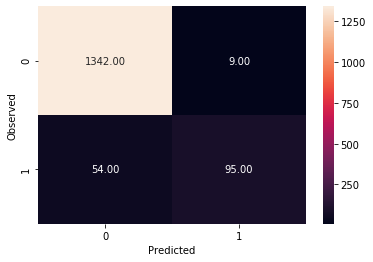

```python
# Plot the confusion matirx.
cm = confusion_matrix(y_test, y_pred)
sns.heatmap(cm, annot=True,  fmt='.2f', xticklabels = [0,1] , yticklabels = [0,1])
plt.ylabel('Observed')
plt.xlabel('Predicted')
plt.show()
```

```python
# Show all the performance metrics.
# Get the mean accuracy of the model.
print("Training Accuracy: {:.4f}".format(logReg.score(X_train, y_train)))
print()
print("Testing Accuracy: {:.4f}".format(logReg.score(X_test, y_test)))
print()
print("Recall: {:.4f}".format(recall_score(y_test, y_pred)))
print()
print("Precision: {:.4f}".format(precision_score(y_test, y_pred)))
print()
print("F1 Score: {:.4f}".format(f1_score(y_test, y_pred)))
print()
print("ROC AUC Score: {:.4f}".format(roc_auc_score(y_test, y_pred)))
print()
```

```
Training Accuracy: 0.9571

Testing Accuracy: 0.9580

Recall: 0.6376

Precision: 0.9135

F1 Score: 0.7510

ROC AUC Score: 0.8155
```

## Step 5

### Threshold

Firstly, it should be noted that the LogisticRegression.predict() function uses a threshold of 0.5 to predict the the outcome of the model. The prediction can be made more strict or less strict by predicting according to higher or lower thresholds respectively. However, the LogisticRegression instance does not facilitate altering the threshold, therefore, the predictions must be made manually using the probability values from LogisticRegression.predict_proba() function. Below is an example of how the threshold can be iterated through to select an optimal value

```python
thresholdSelection_df=pd.DataFrame(columns=["threshold","accuracy", "recall", "precision", "roc_auc_score"])
threshold=[0.1, 0.2, 0.3, 0.4, 0.5, 0.6, 0.7, 0.8, 0.9]
for i in range(len(threshold)):
    manualPrediction = np.where(logReg.predict_proba(X_test)[:,1] > threshold[i], 1, 0)
    row={'threshold':threshold[i],
         'accuracy':accuracy_score(y_test, manualPrediction),
         'recall':recall_score(y_test, manualPrediction),
         'precision':precision_score(y_test, manualPrediction),
         'roc_auc_score':roc_auc_score(y_test, manualPrediction)}
    thresholdSelection_df=thresholdSelection_df.append(row,ignore_index=True)
thresholdSelection_df
```

|  | threshold | accuracy | recall | precision | roc_auc_score |
| --- | --- | --- | --- | --- | --- |
| 0 | 0.1 | 0.901333 | 0.885906 | 0.501901 | 0.894470 |
| 1 | 0.2 | 0.941333 | 0.798658 | 0.672316 | 0.877863 |
| 2 | 0.3 | 0.952000 | 0.724832 | 0.776978 | 0.850943 |
| 3 | 0.4 | 0.956667 | 0.691275 | 0.844262 | 0.838606 |
| 4 | 0.5 | 0.958000 | 0.637584 | 0.913462 | 0.815461 |
| 5 | 0.6 | 0.950000 | 0.550336 | 0.911111 | 0.772207 |
| 6 | 0.7 | 0.946000 | 0.483221 | 0.947368 | 0.740130 |
| 7 | 0.8 | 0.942000 | 0.422819 | 0.984375 | 0.711039 |
| 8 | 0.9 | 0.932667 | 0.322148 | 1.000000 | 0.661074 |

The best threshold can now be selected depending on which metrics we would like to optimise. Coincidently, for our case a threshold of 0.5 results in the highest accuracy. In my opinion, for reasons discussed later, precission must take preference over recall for this model. Therefore, we will keep the default 0.5 threshold.

### Parameters

Next, we must consider the parameters used by the model. Below is a list of the paramters as used in the model above.

```python
# Display the parameters used for the logistic regression.
logReg.get_params()
```

```
{'C': 1.0,
 'class_weight': None,
 'dual': False,
 'fit_intercept': True,
 'intercept_scaling': 1,
 'l1_ratio': None,
 'max_iter': 100,
 'multi_class': 'warn',
 'n_jobs': None,
 'penalty': 'l2',
 'random_state': None,
 'solver': 'liblinear',
 'tol': 0.0001,
 'verbose': 0,
 'warm_start': False}
```

One should explore the use of different parameters in order to obtain the best performance metrics. A simple way to find the optimal value for a parameter is to create models and obtain performance metrics for different values of the parameter.

#### Solver

Checking which solver provides the best performance metrics.

```python
# Iterate through the available 'solver' options.
solver = ['newton-cg','lbfgs', 'liblinear','sag','saga']
solverSelection_df=pd.DataFrame(columns=["solver", "accuracy", "recall", "precision", "roc_auc_score"])
for i in solver:
    model = LogisticRegression(solver=i, max_iter=10000)  # changing values of solver
    # Set the max_iter value high, otherwise some solvers fail to converge.
    model.fit(X_train, y_train)
    model_prediction = model.predict(X_test)
    row={'solver':i,
         'accuracy':accuracy_score(y_test, model_prediction),
         'recall':recall_score(y_test, model_prediction),
         'precision':precision_score(y_test, model_prediction),
         'roc_auc_score':roc_auc_score(y_test, model_prediction)}
    solverSelection_df=solverSelection_df.append(row,ignore_index=True)
```

```python
solverSelection_df
```

|  | solver | accuracy | recall | precision | roc_auc_score |
| --- | --- | --- | --- | --- | --- |
| 0 | newton-cg | 0.958667 | 0.651007 | 0.906542 | 0.821802 |
| 1 | lbfgs | 0.958667 | 0.651007 | 0.906542 | 0.821802 |
| 2 | liblinear | 0.958000 | 0.637584 | 0.913462 | 0.815461 |
| 3 | sag | 0.947333 | 0.543624 | 0.880435 | 0.767741 |
| 4 | saga | 0.941333 | 0.530201 | 0.814433 | 0.758439 |

Solver lbfgs and newton-cg seem to be the best for most metrics. However, lbfgs requires a high value for max_iter to converge, therefore, using newton-cg will be more efficient.

solver = newton-cg.

#### Inverse of regularization strength: C

Iterate through values for the 'C' parameter to obtain the best value.

```python
# Iterate through values of 'C'
cSelection_df=pd.DataFrame(columns=["C","accuracy", "recall", "precision", "roc_auc_score"])
C = [0.01,0.1,0.25,0.5,0.75,1]
for i in C:
    model = LogisticRegression(solver='newton-cg', C=i)  # changing values of C
    model.fit(X_train, y_train)
    model_prediction = model.predict(X_test)
    row={'C':i,
         'accuracy':accuracy_score(y_test, model_prediction),
         'recall':recall_score(y_test, model_prediction),
         'precision':precision_score(y_test, model_prediction),
         'roc_auc_score':roc_auc_score(y_test, model_prediction)}
    cSelection_df=cSelection_df.append(row,ignore_index=True)
```

```python
cSelection_df
```

|  | C | accuracy | recall | precision | roc_auc_score |
| --- | --- | --- | --- | --- | --- |
| 0 | 0.01 | 0.930000 | 0.449664 | 0.744444 | 0.716320 |
| 1 | 0.10 | 0.950667 | 0.563758 | 0.903226 | 0.778548 |
| 2 | 0.25 | 0.956000 | 0.617450 | 0.910891 | 0.805394 |
| 3 | 0.50 | 0.959333 | 0.644295 | 0.923077 | 0.819187 |
| 4 | 0.75 | 0.960000 | 0.651007 | 0.923810 | 0.822543 |
| 5 | 1.00 | 0.958667 | 0.651007 | 0.906542 | 0.821802 |

The best metrics seem to be around 0.75. Do a closer inspection.

```python
# Iterate through values of 'C'
C = [0.5, 0.575, 0.6, 0.625, 0.65, 0.675, 0.7, 0.725, 0.75, 0.775, 0.8, 0.825, 0.85, 0.875, 0.9, 0.925, 0.95, 0.975, 1.0]
cSelection_df=pd.DataFrame(columns=["C","accuracy", "recall", "precision", "roc_auc_score"])
for i in C:
    model = LogisticRegression(solver='newton-cg', C=i)  # changing values of C
    model.fit(X_train, y_train)
    model_prediction = model.predict(X_test)
    row={'C':i,
         'accuracy':accuracy_score(y_test, model_prediction),
         'recall':recall_score(y_test, model_prediction),
         'precision':precision_score(y_test, model_prediction),
         'roc_auc_score':roc_auc_score(y_test, model_prediction)}
    cSelection_df=cSelection_df.append(row,ignore_index=True)
```

```python
cSelection_df
```

|  | C | accuracy | recall | precision | roc_auc_score |
| --- | --- | --- | --- | --- | --- |
| 0 | 0.500 | 0.959333 | 0.644295 | 0.923077 | 0.819187 |
| 1 | 0.575 | 0.960000 | 0.651007 | 0.923810 | 0.822543 |
| 2 | 0.600 | 0.960000 | 0.651007 | 0.923810 | 0.822543 |
| 3 | 0.625 | 0.960000 | 0.651007 | 0.923810 | 0.822543 |
| 4 | 0.650 | 0.960000 | 0.651007 | 0.923810 | 0.822543 |
| 5 | 0.675 | 0.960000 | 0.651007 | 0.923810 | 0.822543 |
| 6 | 0.700 | 0.960000 | 0.651007 | 0.923810 | 0.822543 |
| 7 | 0.725 | 0.960000 | 0.651007 | 0.923810 | 0.822543 |
| 8 | 0.750 | 0.960000 | 0.651007 | 0.923810 | 0.822543 |
| 9 | 0.775 | 0.960000 | 0.651007 | 0.923810 | 0.822543 |
| 10 | 0.800 | 0.960000 | 0.651007 | 0.923810 | 0.822543 |
| 11 | 0.825 | 0.959333 | 0.651007 | 0.915094 | 0.822172 |
| 12 | 0.850 | 0.958667 | 0.651007 | 0.906542 | 0.821802 |
| 13 | 0.875 | 0.958667 | 0.651007 | 0.906542 | 0.821802 |
| 14 | 0.900 | 0.958667 | 0.651007 | 0.906542 | 0.821802 |
| 15 | 0.925 | 0.958667 | 0.651007 | 0.906542 | 0.821802 |
| 16 | 0.950 | 0.958667 | 0.651007 | 0.906542 | 0.821802 |
| 17 | 0.975 | 0.958667 | 0.651007 | 0.906542 | 0.821802 |
| 18 | 1.000 | 0.958667 | 0.651007 | 0.906542 | 0.821802 |

These are all very close, the best metrics seem to be around 0.75.

Select 0.75.

C = 0.75

#### Grid Search

A grid search can also be done to fine the best parameters.

```python
grid_values = {'C': [0.1, 0.15, 0.2, 0.25, 0.3, 0.35, 0.4, 0.45, 0.5, 0.55, 0.6, 0.65, 0.7, 0.75, 0.8, 0.85, 0.9, 0.95, 1],
              'class_weight': [None,'balanced']}
from sklearn.model_selection import GridSearchCV
g=GridSearchCV(LogisticRegression(solver='newton-cg'),param_grid=grid_values, cv=5)
g.fit(X_train,y_train)
g.best_params_
```

```
{'C': 0.75, 'class_weight': None}
```

Hence, our previous selection of 0.75 for C is confirmed.

### Refined Model

```python
# Use Logistic Regression to predict the outcome.
logRegRefined = LogisticRegression(C=0.75, solver='newton-cg')
# Fit the training data to the model.
logRegRefined.fit(X_train, y_train)
# Predict the outcome of the test data.
y_predRefined = logRegRefined.predict(X_test) # Get the prediction based on a 0.5 probability.
y_probRefined = logRegRefined.predict_proba(X_test) # Get the probability.
```

```python
# View the coefficients and the intercept.
coefficientsRefined_df = pd.DataFrame(logRegRefined.coef_)
coefficientsRefined_df['Intercept'] = logRegRefined.intercept_
coefficientsRefined_df
```

|  | 0 | 1 | 2 | 3 | 4 | 5 | 6 | 7 | 8 | 9 | 10 | 11 | Intercept |
| --- | --- | --- | --- | --- | --- | --- | --- | --- | --- | --- | --- | --- | --- |
| 0 | 0.02338 | -0.018209 | 0.055321 | 0.626783 | 0.193261 | 0.00094 | -0.703333 | 2.970257 | -0.515957 | -0.770925 | -3.506962 | 0.003915 | -9.616403 |

```python
# Have a look what columns the coefficients are for.
X_train.head(1)
```

|  | Age | Experience | Income | Family | CCAvg | Mortgage | Securities Account | CD Account | Online | CreditCard | Education_1 | Education_2 |
| --- | --- | --- | --- | --- | --- | --- | --- | --- | --- | --- | --- | --- |
| 1334 | 47 | 22 | 35 | 2 | 1.3 | 0 | 0 | 0 | 1 | 0 | 1 | 0 |

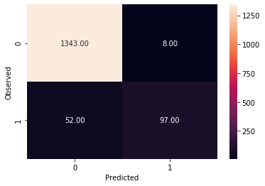

```python
# Plot the confusion matirx.
cmRefined = confusion_matrix(y_test, y_predRefined)
sns.heatmap(cmRefined, annot=True,  fmt='.2f', xticklabels = [0,1] , yticklabels = [0,1])
plt.ylabel('Observed')
plt.xlabel('Predicted')
plt.show()
```

```python
# Show all the performance metrics.
# Get the mean accuracy of the model.
print("Training Accuracy: {:.4f}".format(logRegRefined.score(X_train, y_train)))
print()
print("Testing Accuracy: {:.4f}".format(logRegRefined.score(X_test, y_test)))
print()
print("Recall: {:.4f}".format(recall_score(y_test, y_predRefined)))
print()
print("Precision: {:.4f}".format(precision_score(y_test, y_predRefined)))
print()
print("F1 Score: {:.4f}".format(f1_score(y_test, y_predRefined)))
print()
print("ROC AUC Score: {:.4f}".format(roc_auc_score(y_test, y_predRefined)))
print()
```

```
Training Accuracy: 0.9589

Testing Accuracy: 0.9600

Recall: 0.6510

Precision: 0.9238

F1 Score: 0.7638

ROC AUC Score: 0.8225
```

```python
# Compare the 2 models.
logRegComp_df=pd.DataFrame(columns=["Model","Train Accuracy", "Test Accuracy", "Recall", "Precision", "F1 Score", "roc_auc_score"])
row={'Model':'logReg',
     'Train Accuracy':logReg.score(X_train, y_train),
     'Test Accuracy':logReg.score(X_test, y_test),
     'Recall':recall_score(y_test, y_pred),
     'Precision':precision_score(y_test, y_pred),
     'F1 Score':f1_score(y_test, y_pred),
     'roc_auc_score':roc_auc_score(y_test, y_pred)}
logRegComp_df=logRegComp_df.append(row,ignore_index=True)

row={'Model':'logRegRefined',
     'Train Accuracy':logRegRefined.score(X_train, y_train),
     'Test Accuracy':logRegRefined.score(X_test, y_test),
     'Recall':recall_score(y_test, y_predRefined),
     'Precision':precision_score(y_test, y_predRefined),
     'F1 Score':f1_score(y_test, y_predRefined),
     'roc_auc_score':roc_auc_score(y_test, y_predRefined)}
logRegComp_df=logRegComp_df.append(row,ignore_index=True)
```

```python
logRegComp_df
```

|  | Model | Train Accuracy | Test Accuracy | Recall | Precision | F1 Score | roc_auc_score |
| --- | --- | --- | --- | --- | --- | --- | --- |
| 0 | logReg | 0.957143 | 0.958 | 0.637584 | 0.913462 | 0.750988 | 0.815461 |
| 1 | logRegRefined | 0.958857 | 0.960 | 0.651007 | 0.923810 | 0.763780 | 0.822543 |

There is a slight improvement in the model. All performance metrics have improved.

## Step 6

### Confusion matrix explanation

True Positive (observed=1,predicted=1):

Predicted that the customer will accept the loan and the customer did accept the loan.

False Positive (observed=0,predicted=1):

Predicted that the customer will accept the loan, but the customer did not accept the loan.

True Negative (observed=0,predicted=0):

Predicted that the customer will not accept the loan and the customer did not accept the loan.

False Negative (observed=1,predicted=0):

Predicted that the customer will not accept the loan, but the customer did accaept the loan.

The bank can use the model to predict the amount of revenue which they will make, due to interrest, for the duration of the loan term. A high amount of true positives mean an accurate prediction.

If false positives are high then the bank will predict more innterrest income than they will actually get. This will be bad for financial planning, as the bank may budget incorrectly and over spend.

If false negatives are high then the bank will predict lower income due interrest than they will actually generate. Although this is not ideal for accurate financial planning, the consequences will be that they have more "money in the bank" at the end of the budgeted period. So false negatives are not too bad.

True negatives add to the accuracy of the prediction and thus better financial planning.

Now consider two of the performance metrics of the model.

Recall = TP /(TP + FN)

Precision = TP / (TP + FP)

If False Negatives are high, then the recall value will be low. The bank makes more money than they expected. If False Positives are high, then the precision will be low. The bank makes less money than expected. Therefore, the Precision is more important than the Recall in this case. The accuracy and the precision of our model are quite high, the recall is not high. Since recall is not that important, I would say that the current model is quite good.